# Effect of Government Response on the number of Infected Individuals

Catherine Al Aswad, Ali Alhakeem, Uyen Dao, Long Kim Long

Last Updated 10/22/2020

# I. Introduction

Amid the Coronavirus Disease pandemic in 2020, governments around the world developed a response to aid the citizens of their countries and mitigate the spread of the Severe Acute Respiratory Syndrome Coronavirus 2. This study aims to understand the relationship between the cumulative number of confirmed cases of COVID-19 in different countries, per 10,000 individuals, and the government response of these countries to the outbreak on the 15th of June 2020. A model will be constructed to depict this relationship.

The data used in this study is obtained from The Humanitarian Data Exchange data portal and includes the total population for each country in 2019[^1], the Stringency and Economic Support indices[^2], and the cumulative number of confirmed cases of COVID-19 in different countries[^3] on the 15th of June 2020. When comparing the number of infected individuals in different countries, the population size of these countries need to be considered. So, the study will look at the cumulative number of confirmed cases of COVID-19 in different countries, per 10,000 individuals, and is calculated as:
$$\frac{\text{cumulative cases in the country}}{\text{total population of the country}} \cdot 10,000$$

The continuous variables Stringency Index and the Economic Health Index are used to quantify the government response. The former index accounts for closure, containment, and public health measures, and the latter index accounts for the economic response taken by the governments. Two other indices, Government Response Index and Containment and Health Index, were considered instead of the Economic Health Index; however, the former two indices have 9/13 and 9/11 of their features respectively in common with the Stringency Index, suggesting the presence of high collinearity between the indices, which is not ideal. On the other hand, the Stringency Index and the Economic Health Index are calculated with no features in common. [^4]. Note that the data used provides different government responses for different regions within certain countries, for example the United States of America. Since this study is looking at a country as a whole, the average government response of a country on the 15th of June 2020 will be used, by taking the average government response of all its regions on that day.

After organizing the data, 166 countries remain represented in the dataset on the 15th of June 2020, out of the 195 countries in the world (approximately 85%) [^5]. Knowing this is one of the reasons why the study will focus on the 15th of June 2020. To represent as many countries as possible, a day was chosen with 166 observations, the largest number of observations per day available in the data set. However, there are many such days, so it was decided to choose a day after April 28 2020, since that is when the Stringency index and the Economic Support index were refined and expanded to give a more accurate measure for the government response. Then, looking at some of the factors that are used to calculate the Stringency and Economic support indices - the income support[^6] and dept. or contract relief[^7], stay at home requirements[^8] and international travel control[^9] respectively - there appears to be seasonal patterns for these variables, where they are mostly non changing from May to July and greatly fluctuating before and after this interval. Deciding to focus on the summer season, we took a day at the middle of our May to July interval: the 15th of June 2020.

Table 1.Sample of 5 randomly chosen rows of the data set used in this study

| Country | Stringency_Index | Economic_Support_Index | Population2019 | cumulative_confirmed_cases_per_10000 |
| --- | --- | --- | --- | --- |
| Indonesia | 68.06 | 25.0 | 270625568 | 1.4519692 |
| Serbia | 24.07 | 37.5 | 6944975 | 17.8071195 |
| Djibouti | 53.70 | 12.5 | 973560 | 46.2323842 |
| Madagascar | 70.37 | 25.0 | 26969307 | 0.4783215 |
| Eswatini | 84.26 | 25.0 | 1148130 | 4.4071664 |

# II. Exploratory data analysis

Table 2: Summary for the cumulative confirmed cases per 10,000

| n | min | median | mean | max | sd |
| --- | --- | --- | --- | --- | --- |
| 166 | 0.0091157 | 3.695944 | 16.48795 | 285.5723 | 34.0485 |

Our total sample size was 166 (Table 2). The mean cumulative confirmed cases (CCC) per 10,000 is about 16.48, far greater than our median, indicating that our CCC distribution is heavily right-skewed, which can easily be observed in Figure 1. This is to be expected for the lowest CCC possible is 0 whereas there is no such bound for the highest number. Most countries have their CCC within the 100-mark, we also notice the existence of some very extreme cases (outliers).

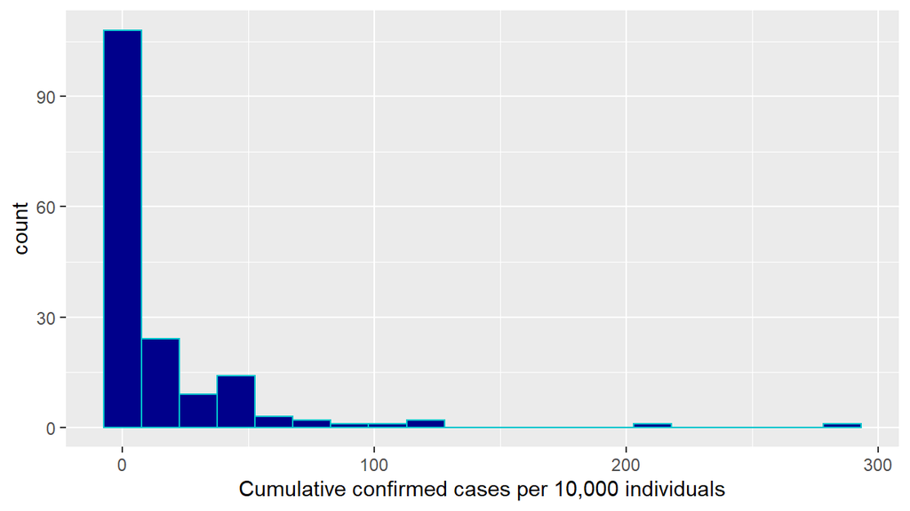

Figure 1. Distribution for the cumulative confirmed cases per 10,000 for individual countries

The distribution of the Stringency Index (Figure 2), which measures government response, seems to resemble a bell shape although there is a slight skew on the left tail. The Economic Support Index distribution (Figure 3), which records measures such as income support and debt relief, also seems to be a bit left-skewed. We notice that there are two modes at 50 and 75, but suspect that could be due to rounding.

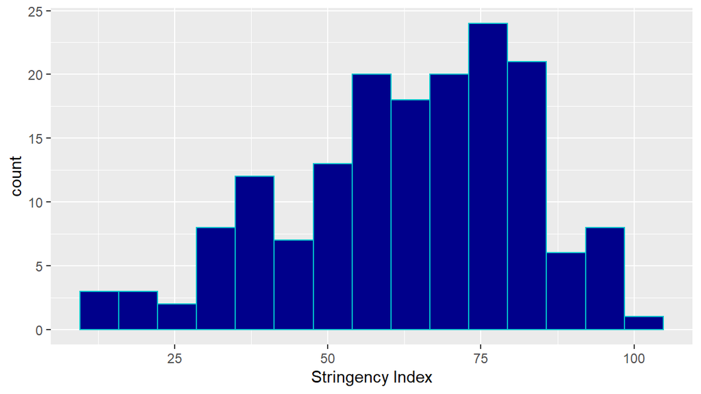

Figure 2. Distribution for the government response measured by the Stringency Index

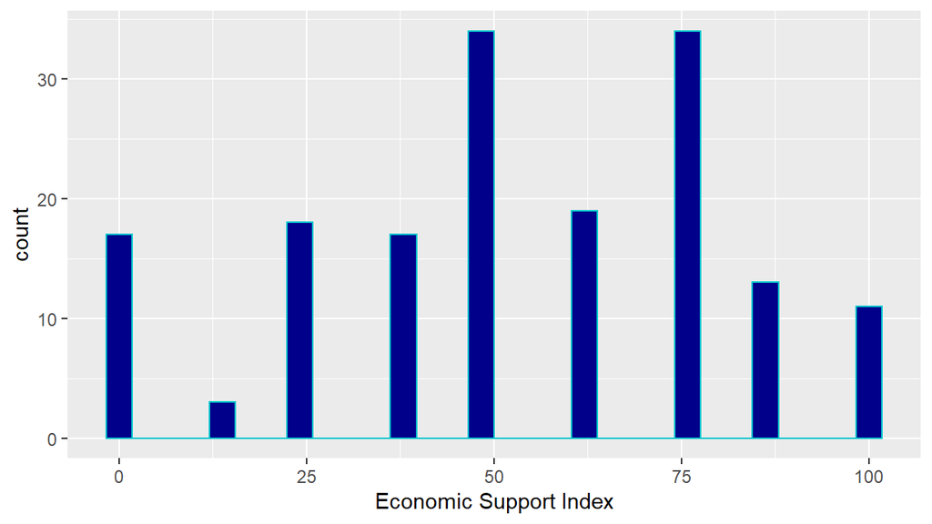

Figure 3. Distribution for the government response measured by the Economic Support Index

In figure 4, the scatterplot for the CCC against Stringency Index has most points clustering in the square box bounded from CCC (0, 50) and Stringency Index (60, 85), which suggests that many countries with a low number of cases per 10,000 tend to be strict with their pandemic response. It is also observed that most points are of a lighter shade of blue, implying that more income support and debt relief packages were implemented in those countries.

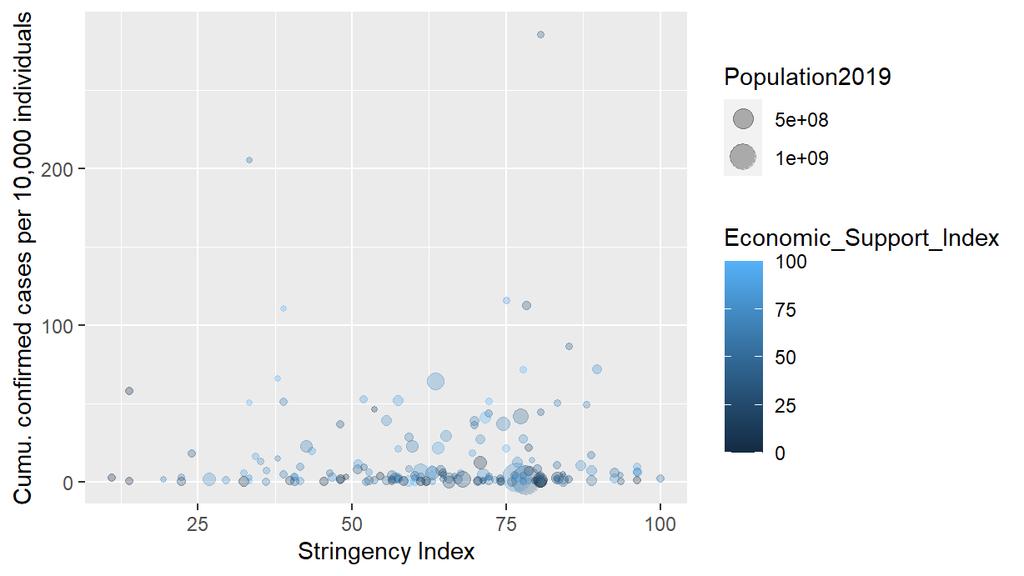

Figure 4. Scatterplot for the cumulative confirmed cases per 10,000 for individual countries against their government response measured by the Stringency Index

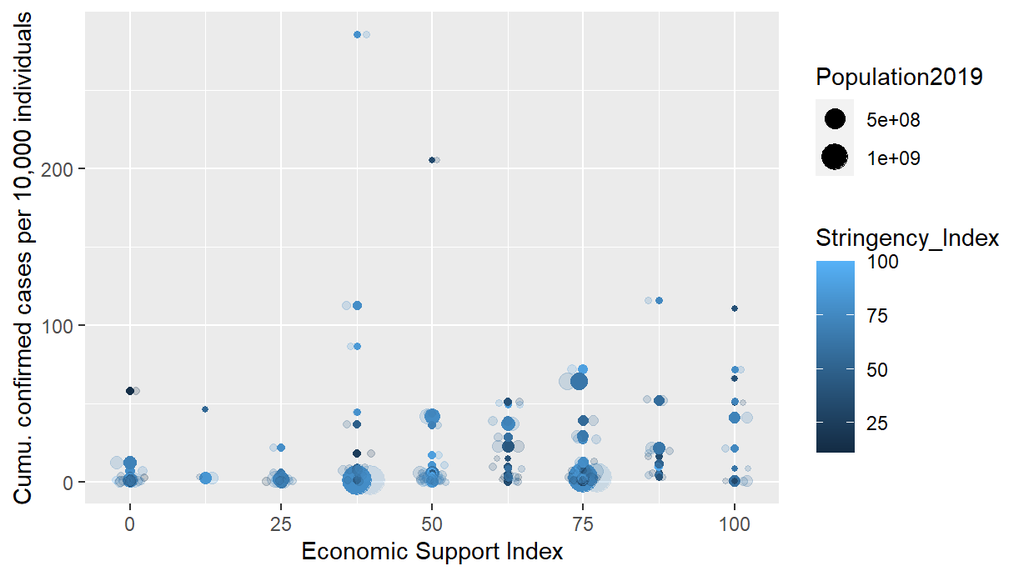

Figure 5. Scatterplot for the cumulative confirmed cases per 10,000 for individual countries against their government response measured by the Economic Support Index

# III. Multiple linear regression

## i. Methods

Our group intends to use a linear model on the given data, then performed a residual analysis, as an in-sample validation method, to detect any systematic departure from the assumptions upon which the model is built: normality, independence, and homoscedasticity of the residuals. In Figure 6, we are presented with a normal QQ-plot of the residuals, which plots the theoretical quantiles against their observed sample counterparts. The graph presents an upward curve, implying that our data is heavily right-skewed. This is confirmed in Figure 7, showing the histogram of the error terms.

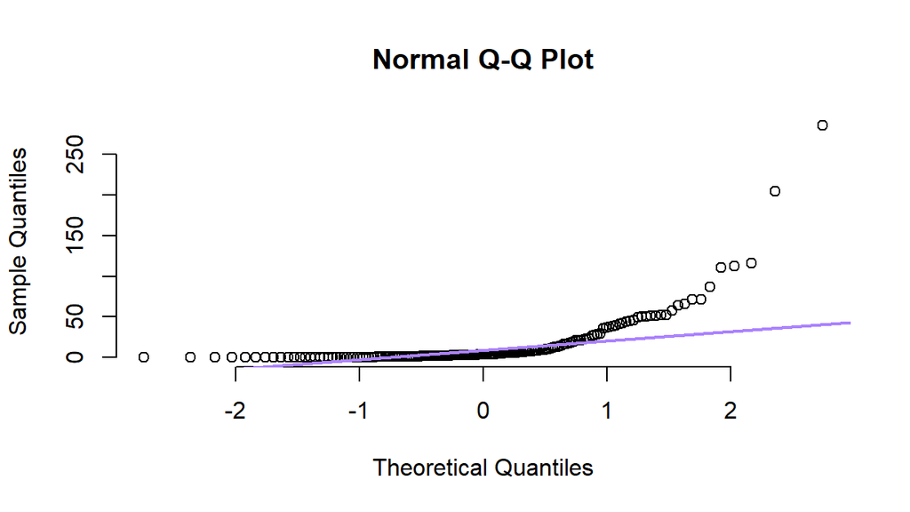

Figure 6. Normal Q-Qplot for the model under discussion

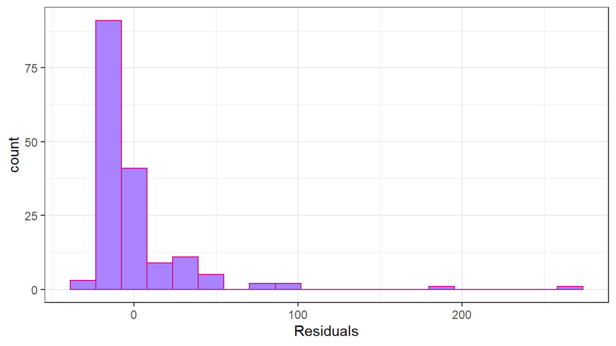

Figure 7. Residuals distribution for the statistical model

Not only that, Figures 8, 9 and 10 present a slight fanning-out pattern of the residuals, implying that the variance is non-constant, or heteroscedasticity.

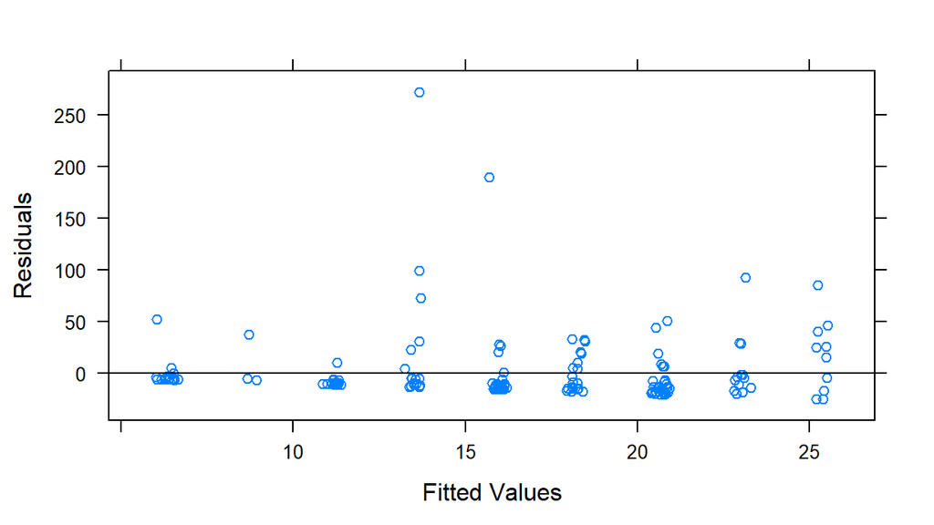

Figure 8. Residuals graph for the fitted values

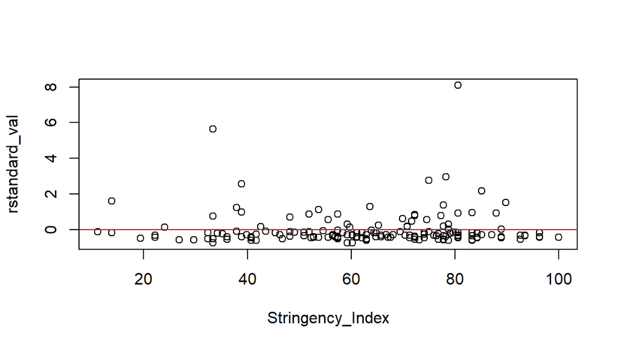

Figure 9. Residuals graph for the Stringency Index

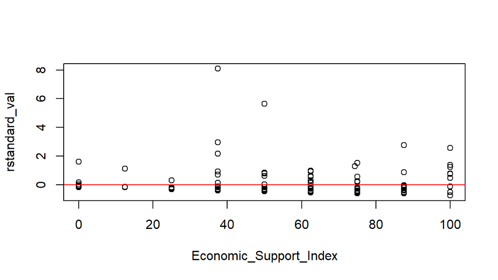

Figure 10. Residuals graph for the Economic Support Index

Due to the violation of the normality and homoscedasticity assumption mentioned above, we recognize that a transformation is much needed. Using the method of log-likelihood (Figure 11), our dependent variable (CCC) will be transformed by the factor of 0.0606. This factor is positive, thus should not be altering the direction of correlation in our inference later on. Note that in Table 2, our min is 0.009 (and not 0), hence our transformation is valid without having to leave out any y value for any country.

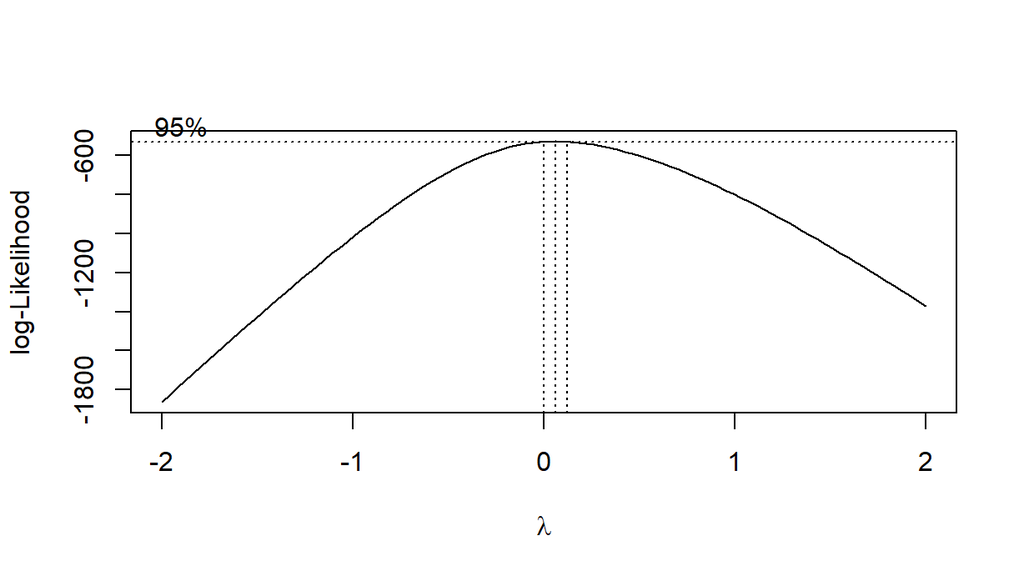

Figure 11. Graph resulting from a Box Cox Test

Comparing the residual graphs (Figure 12 to 16) of the transformed data with what we started with, we observe that the distribution of error terms is fixed to more bell-shaped, the normal Q-Q plot shows an almost straight line, and the residual scatterplot is cloud-shaped (the residuals for Economic support Index is more spread-out). We may conclude that the transformation has allowed our assumptions about the model to be reasonably met in order to proceed with our analysis.

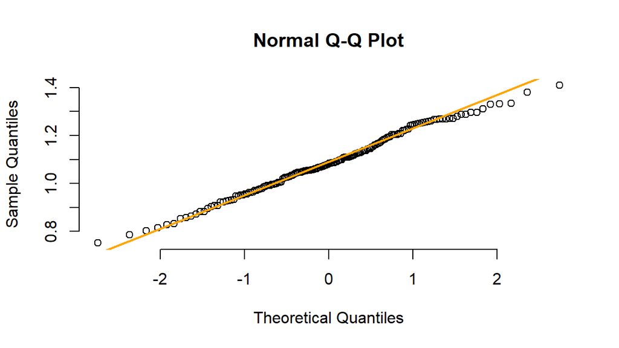

Figure 12. Normal QQplot for transformed model

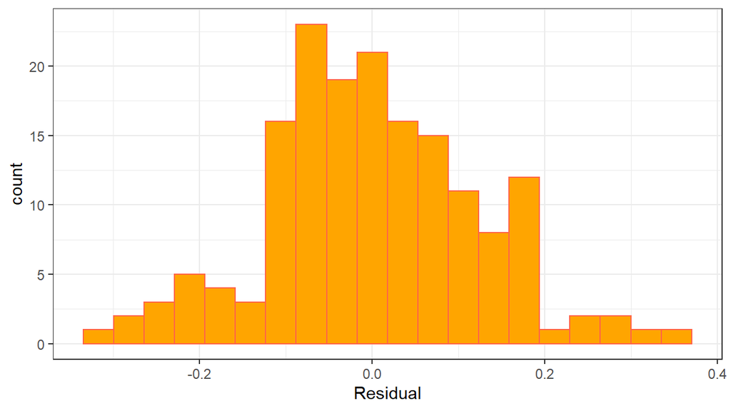

Figure 13. Residuals distribution for the transformed statistical model

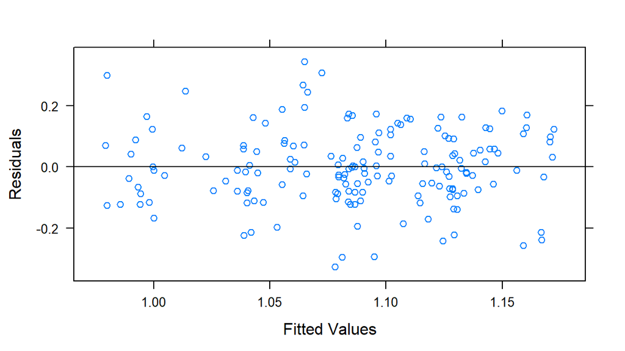

Figure 14. Residuals against the fitted values of the transformed model.

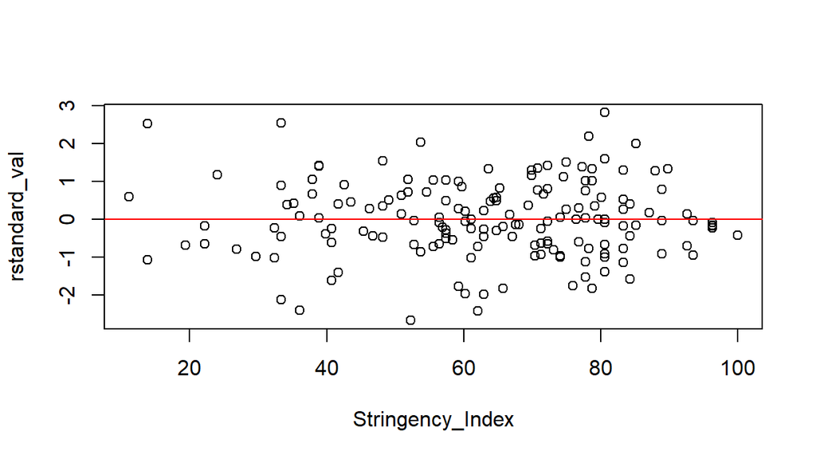

Figure 15. Residuals graph for the Stringency Index after the transformation

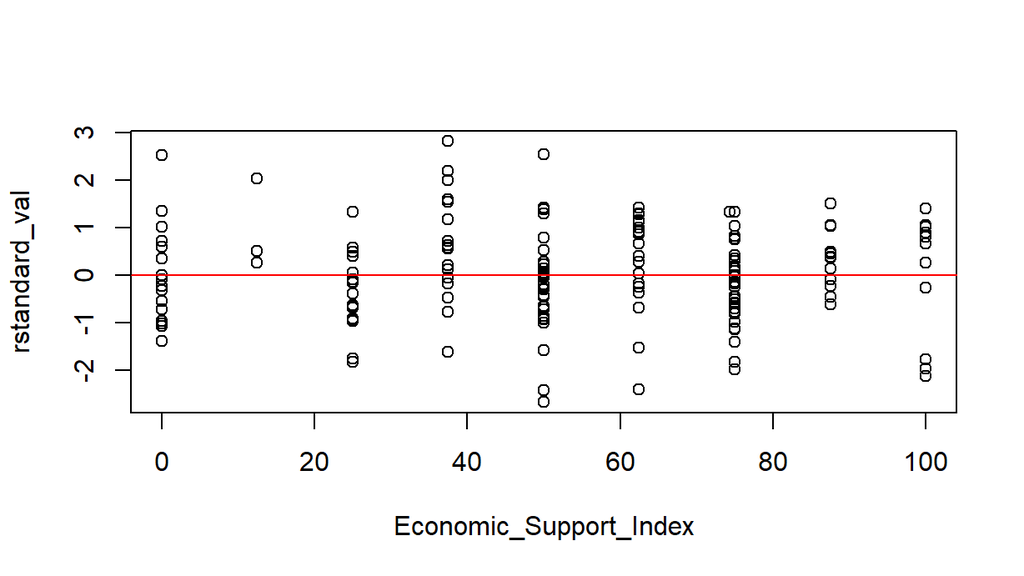

Figure 16. Residuals graph for the Economic Support Index after the transformation

To ensure that multicollinearity is not a problem in the transformed model, the VIF values were calculated for the variables in the transformed model, to check for multicollinearity. It was found that there is little to no multicollinearity, so the study will proceed with the chosen model transformation.

```
##       Stringency_Index Economic_Support_Index
##               1.000684               1.000684
```

## ii. Model Results

Table 3. Model Summary Table

```
##
## Call:
## lm(formula = cumulative_confirmed_cases_per_10000_transf ~ Stringency_Index +
##     Economic_Support_Index, data = tidy_joined_dataset)
##
## Residuals:
##      Min       1Q   Median       3Q      Max
## -0.32585 -0.07954 -0.00482  0.08066  0.34385
##
## Coefficients:
##                         Estimate Std. Error t value Pr(>|t|)
## (Intercept)            0.9758323  0.0377605  25.843  < 2e-16 ***
## Stringency_Index       0.0002994  0.0004933   0.607    0.545
## Economic_Support_Index 0.0017318  0.0003423   5.060 1.12e-06 ***
## ---
## Signif. codes:  0 '***' 0.001 '**' 0.01 '*' 0.05 '.' 0.1 ' ' 1
##
## Residual standard error: 0.1229 on 163 degrees of freedom
## Multiple R-squared:  0.1368, Adjusted R-squared:  0.1262
## F-statistic: 12.91 on 2 and 163 DF,  p-value: 6.231e-06
```

Table 4. The 95% Confidence Intervals

|  | 2.5 % | 97.5 % |
| --- | --- | --- |
| (Intercept) | 0.9012695 | 1.0503950 |
| Stringency_Index | -0.0006747 | 0.0012735 |
| Economic_Support_Index | 0.0010559 | 0.0024077 |

## iii. Interpreting the regression table

Our model is the following:

$$\begin{aligned}\widehat{Y}_{CCPTTH}^{0.061} =& b_{0} + b_{SI} \cdot (x_1) + b_{ESI} \cdot (x_2) \\
= & 0.9758323 + 0.0002994 \cdot (x_1) + 0.0017318 \cdot (x_2)
\end{aligned}$$

+ The intercept ($b_{0}$ = 0.9758323) represents the average number of cases per 10000 to the power of 0.06060606 given a 0 on both the Stringency Index and the Economic Support Index. This does not make sense in our model because of the imposed transformation.

+ The slope estimation for the Stringency Index indicates the rate of change of the average number of cases per 10000 to the power of 0.06060606 increasing by 0.0002994 units with every unit increase of the Stringency Index given the Economic Support Index being equal. This finding is insignificant in our model.

+ The slope estimation for the Economic Support Index indicates that the average number of cases per 10000 to the power of 0.06060606 increases by 0.0017318 units with every unit increase of the Economic Support Index given the Stringency Index being equal.

+ We find our adjusted R-squared to be 0.1262 which is low but does demonstrate some explanation for the observations in comparison to no predictor variables at all given the p-value 6.231e-06 and an F-statistic of 12.91 on 2 and 163 DF. This seems to tell us that it is better than only the mean of confirmed cases per 10000 transformed to the power of 0.06 but it would be better to add more explanatory variables to our model to explain more variability.

## iv. Inference for multiple regression

Using our regression table (Table 3) output we are going to test multiple different null hypotheses. The null hypothesis being that the intercept is zero, while the alternative hypothesis being that the intercept is non-zero and either positive or negative.

$$\begin{aligned} H_0:&\beta_{ESI} = 0 \\\ \mbox{vs }H_A:& \beta_{ESI} \neq 0 \end{aligned}$$

For overall model, we want to test “Is the regression model containing at least one predictor useful in predicting cumulative cases?”. We find out the F-statistic is 12.91 on 2 and 163 DF, with the p-values is 6.231e-06 so we can reject the null hypothesis that there is at least one of the slope parameters in our model is not 0.
$$\begin{aligned} H_0:&\beta_{SI} = \beta_{ESI} = 0 \\\ \mbox{vs }H_A:& \text{ At least one } \beta_{j} \text{is not 0 (for j= SI, ESI)} \end{aligned}$$

The next research question we want to explore is : Is the cumulative cases significantly related to the Economic Support Index controlling for the Stringency Index. From the Anova table, we can calculate the F-statistic using partial F-test:
$$F^* = \frac{ \frac{SSR(x_ESI| x_SI )}{1} }{ \frac{SSE(x_ESI, x_SI )}{n-3} } \approx 25$$

Table 5. ANOVA table for the transformed model

|  | Df | Sum Sq | Mean Sq | F value | Pr(>F) |
| --- | --- | --- | --- | --- | --- |
| Stringency_Index | 1 | 0.0034075 | 0.0034075 | 0.2254582 | 0.6355477 |
| Economic_Support_Index | 1 | 0.3868915 | 0.3868915 | 25.5990654 | 0.0000011 |
| Residuals | 163 | 2.4635007 | 0.0151135 | NA | NA |

There is sufficient evidence (F=25 , P<0.01) to conclude that the Economic Support Index is significantly related to the transformed cumulative cases after taking the Stringency Index in the model.

The 95% Prediction intervals for Stringency Index; for example, a country with a Stringency Index equals to 20, Economic Support Index equal to 50. The cumulative cases per is predicted to be between 0.03882 and 92.30763.

It is similar to other Stringency indices 50,70,90 in the prediction intervals table. In other words, any country with Stringency as 50,70 and 90 (and Economic Support Index equal to 50), the cumulative cases are predicted between the lower and upper band in the table below.

Table 6. The 95% Prediction intervals where Stringency Index = 20, 50, 70, 90, respectively, for transformed cumulative confirmed cases per 10,000 = 1.2, and economic support index = 50.

| SI | fit | lwr | upr |
| --- | --- | --- | --- |
| 20 | 2.97976 | 0.03882 | 92.30763 |
| 50 | 3.42117 | 0.04959 | 99.12208 |
| 70 | 3.74880 | 0.05610 | 106.45159 |
| 90 | 4.10574 | 0.06150 | 116.50780 |

# IV. Discussion

## i. Conclusions

Our analysis shows that there seems to be some relationship between the total confirmed cases per 10,000 and the Stringency and Economic Support Indices of a country measured on the same day. While our results cannot conclude anything about the relationship between Stringency Index and the total cases per 10,000 people, we have enough evidence to say that there is a positive correlation between CCC and the Economic Support Index, which aligns with our expectation, for it is reasonable for a government to spend more budget on income support packages if their people are more impacted by the pandemic.

We also acknowledge that by building our model using data recorded on the same day, we have introduced a lack of a time lag in between the government response and the results, as we cannot expect the response to take effect immediately, thus lessen the effectiveness of our model.

## ii. Limitations

The adequacy of the sample used is questionable. Even though it represents approximately 85% of all the countries in the World, it fails to represent groups of countries properly, for example by continent or socio-economic regions. Thus, the sample was not properly adjusted to account for the countries with missing data.

A common limitation when it comes to unorganized data is the way in which the data is recorded and categorized. The data sets used in this study for the confirmed cases of COVID-19 and the indices do not include data for every country registered in the World Bank (the population data set has countries only registered in the World Bank). For example, the Maldives does not have an entry in the data set for the Stringency and Economic Support indices, when it does have an entry in the other two data sets. If there were missing data for which the indices could not be calculated for this country, then the country would still be in the data set but will have NA values, as is the case with other countries in the data set. Using data that was not gathered for the specific purpose of this study is a limitation since inconsistencies such as these are inevitable.

The model should not be generalized to data sets for other days, since no test was applied to the model to check if it could be generalized. Moreover, the model was not validated using another sample, so its adequacy can be questioned further.

Other non-linear models, such as higher degree polynomial regression models, were considered. It was decided to go with the simpler model to avoid overfitting the data and avoid unnecessarily over complicating the analysis.

## iii. Further questions

The predictor variables used in our model did not explain a lot of the variation in the data. The model can be greatly improved and become more helpful if other predictor variables are added. Variables that were not used to calculate the Stringency and Economic Support Indices could be looked into, since they will probably not have a strong correlation with the indices already in the model.

Moreover, a stepwise model can be explored due to the natural breaks in the Economic Support Index, or polynomial regression models of higher degree can be explored to try and explain more variability in the data. Lastly, this report took the government response and cumulative cases from the same day; a future study can look at the government response decided on a past date and see their effect on the number of infected individuals on a date after the implementation of the response.

# V. Citations and References

[^1]: “Total Population” World Bank Indicators of Interest to the COVID-19 Outbreak. COVID-19 Pandemic. *World Bank*. United Nations Office for the Coordination of Humanitarian Affairs. 2020. Accessed October 2020 https://data.humdata.org/dataset/novel-coronavirus-2019-ncov-cases
[^2]: “OxCGRT_CSV” OXFORD COVID-19 Government Response Stringency index, COVID-19 Pandemic. *The Oxford COVID-19 Government Response Tracker*. United Nations Office for the Coordination of Humanitarian Affairs. 2020. Accessed October 2020 https://data.humdata.org/dataset/oxford-covid-19-government-response-tracker
[^3]: “time_series_covid19_confirmed_global.csv” Novel Coronavirus (COVID-19) Cases Data. COVID-19 Pandemic. *Johns Hopkins University Center for Systems Science and Engineering (JHU CCSE)*. United Nations Office for the Coordination of Humanitarian Affairs. 2020. Accessed October 2020 https://data.humdata.org/dataset/novel-coronavirus-2019-ncov-cases
[^4]: “Methodology for calculating indices” OXFORD COVID-19 Government Response Stringency index, COVID-19 Pandemic, Index methodology version 3.1. *The Oxford COVID-19 Government Response Tracker.* United Nations Office for the Coordination of Humanitarian Affairs. 25 May 2020. Accessed October 2020 https://github.com/OxCGRT/covid-policy-tracker/blob/master/documentation/index_methodology.md
[^5]: “How many Countries are there in the World?”, Worldometer, 2020. Accessed October 2020 https://www.worldometers.info/geography/how-many-countries-are-there-in-the-world/
[^6]: “Income support during the COVID-19 pandemic” Coronavirus pandemic, *Our World in Data*, 2020. Accessed October 2020 https://ourworldindata.org/grapher/income-support-covid?time=2020-06-19
[^7]: “Dept or contract relief during the COVID-19 pandemic” Coronavirus pandemic, *Our World in Data*, 2020. Accessed October 2020 https://ourworldindata.org/grapher/debt-relief-covid?time=2020-06-26
[^8]: “Stay-at-home requirements during the COVID-19 pandemic” Coronavirus pandemic, *Our World in Data*, 2020. Accessed October 2020 https://ourworldindata.org/grapher/stay-at-home-covid?time=2020-07-21
[^9]: “International travel controls during the COVID-19 pandemic” Coronavirus pandemic, *Our World in Data*, 2020. Accessed October 2020 https://ourworldindata.org/grapher/international-travel-covid?time=2020-06-23